# Population Health and economic consequences impact of climatic events in the U.S from 1950 to november 2011

## Synopsis

In this report we aim to describe which type of weather events are most harmful to population health across the U.S. We als aim to describle which type of weather events have the greatest economic consequences. To investigate this hypothesis, we explore the NOAA Storm Database. This database tracks characteristics of major storms and weather events in the United States, including when and where they occur, as well as estimates of any fatalities, injuries, and property damage. From these data, we found that, in total across the U.S., the most harmful events are tornados, involved in 65% of the total injuries and in 37.2% of the total fatalities. About economy, we found that Floods have the greatest economic consequences with a cost of 150 billion dollars, which represents 31.5% of the total damages.

## 1 : Loading and Processing the Raw Data

**1.1 Required libraries**

```r
library(dplyr)
library(ggplot2)
```

**1.2 Downloading and reading data**

Firstly, we read in the raw data file which is downloaded and saved in the R working directory. The data is stored as object “StormData.csv.bz2”.

```r
url <- "https://d396qusza40orc.cloudfront.net/repdata%2Fdata%2FStormData.csv.bz2"
download.file(url, "StormData.csv.bz2",method = "auto")
data <- tbl_df(read.csv("StormData.csv.bz2"))

data
```

```
## # A tibble: 902,297 x 37
##    STATE__           BGN_DATE BGN_TIME TIME_ZONE COUNTY COUNTYNAME  STATE
##      <dbl>             <fctr>   <fctr>    <fctr>  <dbl>     <fctr> <fctr>
##  1       1  4/18/1950 0:00:00     0130       CST     97     MOBILE     AL
##  2       1  4/18/1950 0:00:00     0145       CST      3    BALDWIN     AL
##  3       1  2/20/1951 0:00:00     1600       CST     57    FAYETTE     AL
##  4       1   6/8/1951 0:00:00     0900       CST     89    MADISON     AL
##  5       1 11/15/1951 0:00:00     1500       CST     43    CULLMAN     AL
##  6       1 11/15/1951 0:00:00     2000       CST     77 LAUDERDALE     AL
##  7       1 11/16/1951 0:00:00     0100       CST      9     BLOUNT     AL
##  8       1  1/22/1952 0:00:00     0900       CST    123 TALLAPOOSA     AL
##  9       1  2/13/1952 0:00:00     2000       CST    125 TUSCALOOSA     AL
## 10       1  2/13/1952 0:00:00     2000       CST     57    FAYETTE     AL
## # ... with 902,287 more rows, and 30 more variables: EVTYPE <fctr>,
## #   BGN_RANGE <dbl>, BGN_AZI <fctr>, BGN_LOCATI <fctr>, END_DATE <fctr>,
## #   END_TIME <fctr>, COUNTY_END <dbl>, COUNTYENDN <lgl>, END_RANGE <dbl>,
## #   END_AZI <fctr>, END_LOCATI <fctr>, LENGTH <dbl>, WIDTH <dbl>, F <int>,
## #   MAG <dbl>, FATALITIES <dbl>, INJURIES <dbl>, PROPDMG <dbl>,
## #   PROPDMGEXP <fctr>, CROPDMG <dbl>, CROPDMGEXP <fctr>, WFO <fctr>,
## #   STATEOFFIC <fctr>, ZONENAMES <fctr>, LATITUDE <dbl>, LONGITUDE <dbl>,
## #   LATITUDE_E <dbl>, LONGITUDE_ <dbl>, REMARKS <fctr>, REFNUM <dbl>
```

Now, by exploring our data and reading the National Weather Service [Storm Data Documentation] (https://d396qusza40orc.cloudfront.net/repdata%2Fpeer2_doc%2Fpd01016005curr.pdf), we identify three columns (EVTYPE, INJURIES and FATALITIES) we’d like to subset in order to show which events are most harmful to population Health. We create two dataframes (injuries and fatalities), both grouped by the sum of injuries for each event type (EVTYPE). We also decide to order the data from most injuries to lowest injuries :

```r
injuries <- data %>%
        select(EVTYPE, INJURIES) %>%
        group_by(EVTYPE) %>%
        summarize(sum_injuries = sum(INJURIES)) %>%
        arrange(desc(sum_injuries))
head(injuries)
```

```
## # A tibble: 6 x 2
##           EVTYPE sum_injuries
##           <fctr>        <dbl>
## 1        TORNADO        91346
## 2      TSTM WIND         6957
## 3          FLOOD         6789
## 4 EXCESSIVE HEAT         6525
## 5      LIGHTNING         5230
## 6           HEAT         2100
```

```r
fatalities <- data %>%
        select(EVTYPE, FATALITIES) %>%
        group_by(EVTYPE) %>%
        summarize(sum_fatalities = sum(FATALITIES)) %>%
        arrange(desc(sum_fatalities))
head(fatalities)
```

```
## # A tibble: 6 x 2
##           EVTYPE sum_fatalities
##           <fctr>          <dbl>
## 1        TORNADO           5633
## 2 EXCESSIVE HEAT           1903
## 3    FLASH FLOOD            978
## 4           HEAT            937
## 5      LIGHTNING            816
## 6      TSTM WIND            504
```

Now we need to focus on economic aspect but the data provides two types of economic impact, namely property damage (PROPDMG) and crop damage (CROPDMG). The actual damage in $USD is indicated by PROPDMGEXP and CROPDMGEXP parameters with these values :

```r
table(data$PROPDMGEXP)
```

```
##
##             -      ?      +      0      1      2      3      4      5
## 465934      1      8      5    216     25     13      4      4     28
##      6      7      8      B      h      H      K      m      M
##      4      5      1     40      1      6 424665      7  11330
```

Thanks to this [study] (https://rstudio-pubs-static.s3.amazonaws.com/58957_37b6723ee52b455990e149edde45e5b6.html), the different symbols in PROPDMGEXP and CROPDMGEXP can be read as :

H, h -> hundreds = x100 K, K -> kilos = x1,000 M, m -> millions = x1,000,000 B,b -> billions = x1,000,000,000 (+) -> x1 (-) -> x0 (?) -> x0 blank -> x0 1:9 -> x10

Still, we need to create a function to convert this symbols to numeric values with :

```r
multiplier <- function(x) {
        if (x %in% c("H", "h"))
                return(100)
        else if (x %in% c("K", "k"))
                return(1000)
        else if (x %in% c("M", "m"))
                return(1000000)
        else if (x %in% c("B", "b"))
                return(1000000000)
        else if (x %in% c("+"))
                return (1)
        else if (x %in% c("0", "1", "2", "3", "4", "5", "6", "7", "8", "9"))
                return (10)
        else
                return(0)
}
```

We can apply our function to our different columns we need to convert :

```r
data$PROPmultiplier <- sapply(data$PROPDMGEXP, FUN = multiplier)
data$CROPmultiplier <- sapply(data$CROPDMGEXP, FUN = multiplier)
```

We’re close to the data we want for economics but we still need to multiply PROPDMG with PROPmultiplier and CROPDMG with CROPmultiplier. Once it’s done we create a new colum TOTALDMG by suming poperty damages (PROPDMG) and Crop damages (CROPDMG)

```r
economy <- data %>%
        select(EVTYPE, PROPDMG, PROPmultiplier, CROPDMG, CROPmultiplier) %>%
        filter(PROPmultiplier > 0 | CROPmultiplier > 0) %>%
        mutate(PROPDMG = PROPDMG * PROPmultiplier, CROPDMG = CROPDMG * CROPmultiplier) %>%
        mutate(TOTALDMG = PROPDMG + CROPDMG)
head(economy)
```

```
## # A tibble: 6 x 6
##    EVTYPE PROPDMG PROPmultiplier CROPDMG CROPmultiplier TOTALDMG
##    <fctr>   <dbl>          <dbl>   <dbl>          <dbl>    <dbl>
## 1 TORNADO   25000           1000       0              0    25000
## 2 TORNADO    2500           1000       0              0     2500
## 3 TORNADO   25000           1000       0              0    25000
## 4 TORNADO    2500           1000       0              0     2500
## 5 TORNADO    2500           1000       0              0     2500
## 6 TORNADO    2500           1000       0              0     2500
```

Our data is now a bit more readable but we need to rework on this dataframe so we can sum the data (TOTALDMG) by type of event (EVTYPE). Please note we divide the sum by a billion to make our future plot easier to read :

```r
economy2 <- economy %>%
        group_by(EVTYPE) %>%
        summarize(sum_TOTALDMG = sum(TOTALDMG) / 10^9) %>%
        arrange(desc(sum_TOTALDMG))
head(economy2)
```

```
## # A tibble: 6 x 2
##              EVTYPE sum_TOTALDMG
##              <fctr>        <dbl>
## 1             FLOOD    150.31968
## 2 HURRICANE/TYPHOON     71.91371
## 3           TORNADO     57.35212
## 4       STORM SURGE     43.32354
## 5              HAIL     18.75822
## 6       FLASH FLOOD     17.56213
```

That’s the final dataframe we need to explore the economic consequences of climatic events.

## 2 : Results

**2.1 Across the United States, which types of events are most harmful with respect to population health ?**

In order to show which events are most harmful, we need to specify how many events we’d like to show. Indeed, as you can see, we have 985 different type of events :

```r
nrow(injuries)
```

```
## [1] 985
```

We can’t display 985 events, it’s too much. We need to check which of the top values are the most influential. Let’s try with the top 5 events resulting in most injuries :

```r
top5_most_injuries <- sum(injuries$sum_injuries[1:5])
Total_injuries <- sum(injuries$sum_injuries)
mean(top5_most_injuries / Total_injuries * 100)
```

```
## [1] 83.14855
```

83.1 means we display 83.1% of the impacted events with this top 5, not bad. What about the top 10 ?

```r
top10_most_injuries <- sum(injuries$sum_injuries[1:10])
mean(top10_most_injuries / Total_injuries * 100)
```

```
## [1] 89.3402
```

89.3 meaning our top 10 is very influential with 89.3% of the injuries resulting from it. Let’s show this :

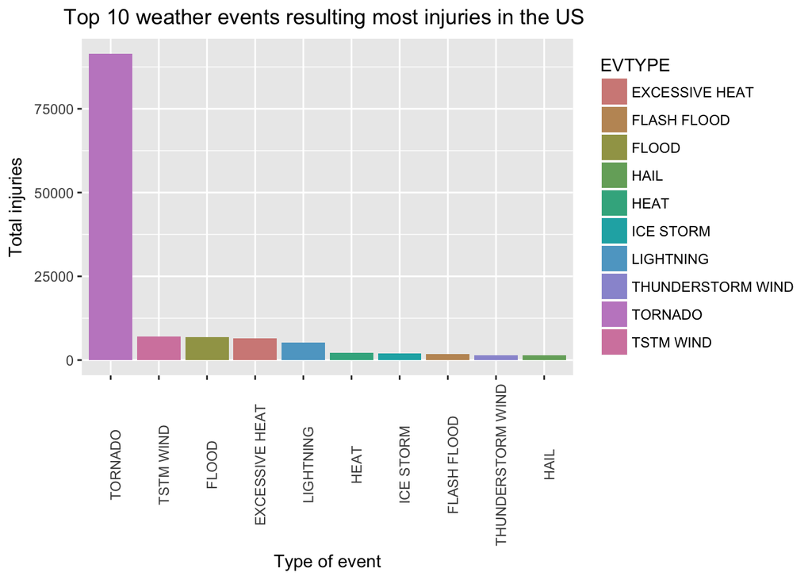

```r
injuries_plot <- ggplot(injuries[1:10, ], aes(x = reorder(EVTYPE, -sum_injuries), y = sum_injuries, fill = EVTYPE)) +
        geom_bar(stat = "identity") +
        theme(axis.text.x = element_text(angle = 90)) +
        labs(x = "Type of event", y = "Total injuries", title = "Top 10 weather events resulting most injuries in the US ") +
        theme(plot.title = element_text(hjust = 0.5)) +
        scale_fill_hue(c = 50)

injuries_plot
```

By watching this figure, we clearly identify our most influential climatic event causing the most injuries, tornados.

What’s the percentage of tornados compared to the whole climatic events ?

```r
Most_injuries <- sum(injuries$sum_injuries[1])
mean(Most_injuries / Total_injuries * 100)
```

```
## [1] 65.00199
```

Tornados caused 65% (almost 2/3) of the total injuries due to climatic events.

We have another variable we can explore, fatalities. Let’s display our top 10 biggest infulential events :

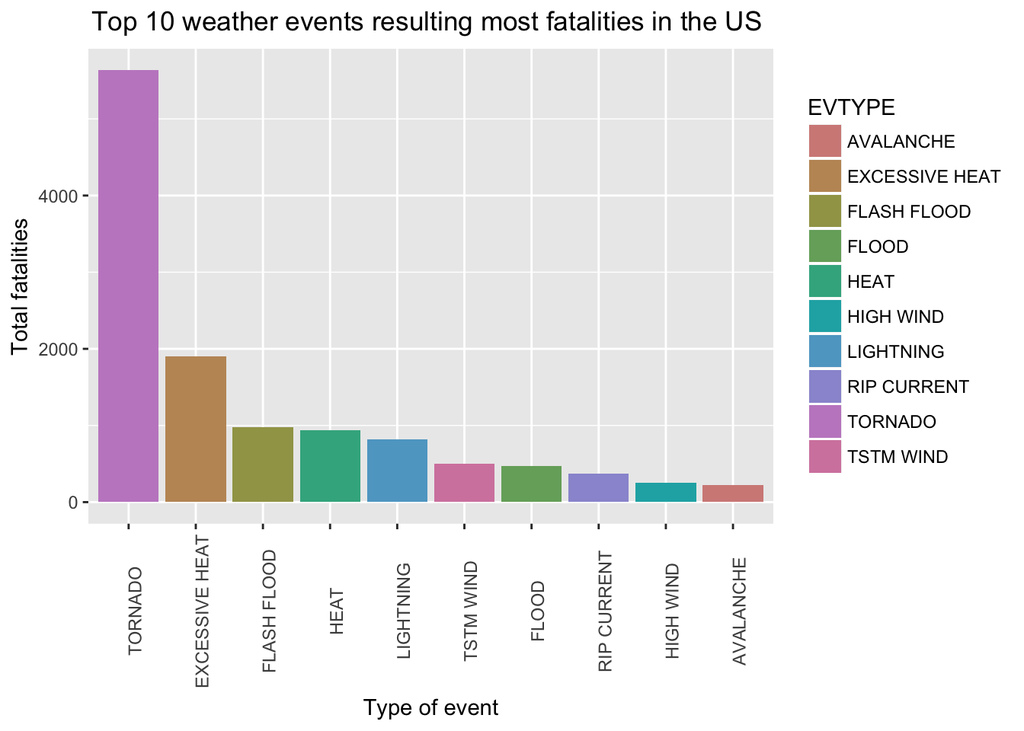

```r
fatalities_plot <- ggplot(fatalities[1:10, ], aes(x = reorder(EVTYPE, -sum_fatalities), y = sum_fatalities, fill = EVTYPE)) +
        geom_bar(stat = "identity") +
        theme(axis.text.x = element_text(angle = 90)) +
        labs(x = "Type of event", y = "Total fatalities", title = "Top 10 weather events resulting most fatalities in the US ") +
        theme(plot.title = element_text(hjust = 0.5)) +
        scale_fill_hue(c = 50)

fatalities_plot
```

It shows almost the same pattern as fatalities but with more spread, with tornados as the main cause of climatic fatalities in the US since 1950. How influential tornados are ? Will it confirm data is more spread ?

```r
Most_fatalities <- fatalities$sum_fatalities[1]
Total_fatalities <- sum(fatalities$sum_fatalities)
mean(Most_fatalities / Total_fatalities * 100)
```

```
## [1] 37.19379
```

37.2%, this is much less significant than the percentage of injuries caused by tornados, confirming our data is more on spread in this figure. Maybe most of the people injured by tornados were just slightly wounded, it could explain why the data is more spread.

How about the 10 events causing the most fatalities ?

```r
top10_most_fatalities <- sum(fatalities$sum_fatalities[1:10])
mean(top10_most_fatalities / Total_fatalities * 100)
```

```
## [1] 79.7689
```

Once again, the top 10 events are involved in 79.8% of the total fatalities due to climatic events.

**2.2 Across the United States, which types of events have the greatest economic consequences ?**

As we did for the population Health, we display the top 10 values :

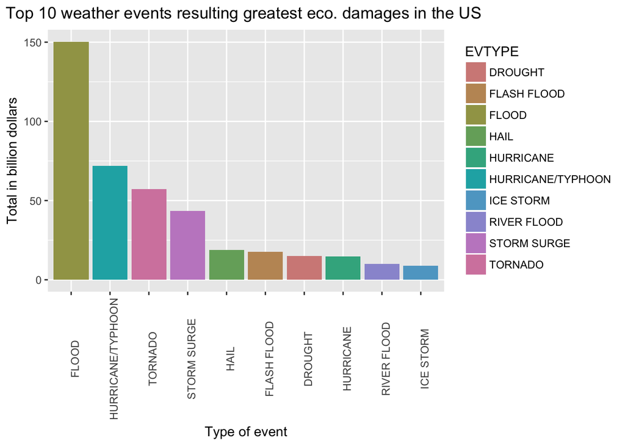

```r
Economics_plot <- ggplot(economy2[1:10, ], aes(x = reorder(EVTYPE, -sum_TOTALDMG), y = sum_TOTALDMG, fill = EVTYPE)) +
        geom_bar(stat = "identity") +
        theme(axis.text.x = element_text(angle = 90)) +
        labs(x = "Type of event", y = "Total in billion dollars", title = "Top 10 weather events resulting greatest eco. damages in the US ") +
        theme(plot.title = element_text(hjust = 0.5)) +
        scale_fill_hue(c = 50)

Economics_plot
```

As tornado is the most influential event over population Health, we could think it would be the same for economic damages but it’s not. Tornado is at the 3rd place of this rank but still caused more than 57 billions of dollars of damages. Floods are having the greatest economic impact with a total 150 billions of dollars of damages.

How much does flood represent compared to the total damages ?

```r
Most_Economics <- economy2$sum_TOTALDMG[1]
Total_Economics <- sum(economy2$sum_TOTALDMG)
mean(Most_Economics / Total_Economics * 100)
```

```
## [1] 31.55173
```

We can impute 1/3 of the total damages to floods. How about the greatest 10 ?

```r
top10_Most_Economics <- sum(economy2$sum_TOTALDMG[1:10])
mean(top10_Most_Economics / Total_Economics * 100)
```

```
## [1] 85.63269
```

The 10 most influential climatic events are responsible for 85.6% of the total damages due to climatic events.